# Matlab FF_DS_AZ_CTS_LOOP Looped Exact Solution for the Stationary Distribution of Optimal Savings Dynamic Programming Problem

[Fan Wang](https://fanwangecon.github.io/)

2020-07-25

# 1 FF_DS_AZ_CTS_LOOP Dynamic Savings Loop Continuous Distribution

> Go to the [**MLX**](https://github.com/FanWangEcon//MEconTools/blob/master/MEconTools/doc/ds//fx_ds_az_cts_loop.mlx), [**M**](https://github.com/FanWangEcon//MEconTools/blob/master/MEconTools/doc/ds//htmlpdfm/fx_ds_az_cts_loop.m), [**PDF**](https://github.com/FanWangEcon//MEconTools/blob/master/MEconTools/doc/ds//htmlpdfm/fx_ds_az_cts_loop.pdf), or [**HTML**](https://fanwangecon.github.io//MEconTools/MEconTools/doc/ds//htmlpdfm/fx_ds_az_cts_loop.html) version of this file. Go back to [fan](http://fanwangecon.github.io/)’s [MEconTools](https://fanwangecon.github.io/MEconTools/) Toolbox (bookdown), [Matlab Code Examples](https://fanwangecon.github.io/MEconTools/) Repository (bookdown), or [Math for Econ with Matlab](https://fanwangecon.github.io/Math4Econ/) Repository (bookdown).

This is the example vignette for function: [**ff_ds_az_cts_loop**](https://github.com/FanWangEcon/MEconTools/blob/master/MEconTools/vfi/ff_ds_az_cts_loop.m) from the [**MEconTools Package**](https://fanwangecon.github.io/MEconTools/)**.** F(a,z) discrete probability mass function given policy function solution with continuous savings choices.

- Distribution for Common Choice and States Grid : ff_ds_az_cts_loop
- Distribution for States Grid + Continuous Exact Savings as Share of Cash-on-Hand : [**ff_ds_az_cts_loop**](https://github.com/FanWangEcon/MEconTools/blob/master/MEconTools/vfi/ff_ds_az_cts_loop.m)

## 1.1 Test FF_DS_AZ_CTS_LOOP Defaults

Call the function with defaults. By default, shows the asset policy function summary. Model parameters can be changed by the mp_params.

```
%mp_params
mp_params = containers.Map('KeyType','char', 'ValueType','any');
mp_params('fl_crra') = 1.5;
mp_params('fl_beta') = 0.94;
% call function
ff_ds_az_cts_loop(mp_params);

Elapsed time is 1.029654 seconds.
----------------------------------------
xxxxxxxxxxxxxxxxxxxxxxxxxxxxxxxxxxxxxxxx
CONTAINER NAME: mp_ffcmd ND Array (Matrix etc)
xxxxxxxxxxxxxxxxxxxxxxxxxxxxxxxxxxxxxxxx
          i    idx    ndim    numel    rowN    colN     sum       mean      std      coefvari    min     max
          _    ___    ____    _____    ____    ____    ______    ______    ______    ________    ___    ______

    ap    1     1      2       700     100      7      9863.4    14.091    14.388     1.0211      0     50.117

xxx TABLE:ap xxxxxxxxxxxxxxxxxx
              c1        c2        c3         c4         c5         c6         c7
            ______    ______    ______    ________    _______    _______    ______

    r1           0         0         0    0.053491    0.25574    0.60604    1.1157
    r2           0         0         0    0.053998    0.25571     0.6066    1.1163
    r3           0         0         0    0.056449    0.25576    0.60907    1.1187
    r4           0         0         0    0.061799    0.26016     0.6109    1.1239
    r5           0         0         0    0.066463    0.26897    0.61141    1.1327
    r96     43.388     43.52    43.701      43.925     44.222      44.68    45.228
    r97     44.566    44.695    44.878      45.103     45.398     45.856    46.403
    r98     45.761    45.892    46.072      46.298     46.592      47.05    47.597
    r99     46.973    47.107    47.286      47.514     47.806     48.263    48.815
    r100    48.206    48.338    48.519      48.746     49.037     49.497    50.117

FF_DS_AZ_CTS_LOOP finished. Distribution took = 0.25795
----------------------------------------
xxxxxxxxxxxxxxxxxxxxxxxxxxxxxxxxxxxxxxxx
CONTAINER NAME: mp_ddcmd ND Array (Matrix etc)
xxxxxxxxxxxxxxxxxxxxxxxxxxxxxxxxxxxxxxxx
           i    idx    ndim    numel    rowN    colN    sum      mean         std       coefvari       min          max
           _    ___    ____    _____    ____    ____    ___    _________    ________    ________    __________    _______

```

[output cut: 30 more lines]

```
    r98      5.734e-25    1.6065e-23    1.9875e-22    1.3596e-21    5.2668e-21     1.075e-20     9.414e-21
    r99     4.7136e-26    1.4644e-24    1.9531e-23    1.4042e-22    5.6108e-22    1.1675e-21    1.0348e-21
    r100    1.9078e-27    7.8348e-26    1.2906e-24    1.0816e-23    4.8188e-23    1.0831e-22    1.0098e-22

xxx TABLE:fz xxxxxxxxxxxxxxxxxx
             c1
          ________

    r1    0.015625
    r2     0.09375
    r3     0.23438
    r4      0.3125
    r5     0.23438
    r6     0.09375
    r7    0.015625
```

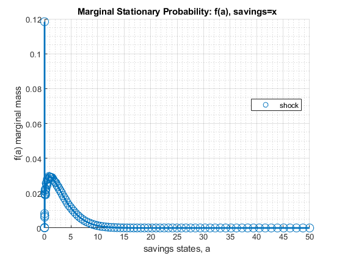

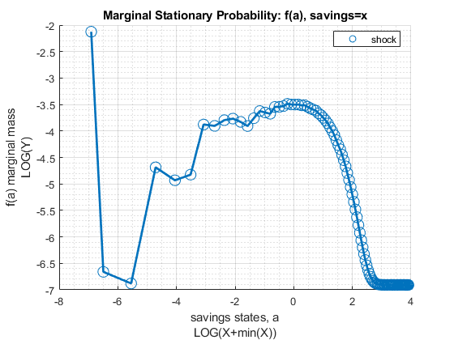

```
xxx tb_outcomes: all stats xxx
    OriginalVariableNames         ap            v             c             y            coh        savefraccoh
    ______________________    __________    __________    __________    __________    __________    ___________

    {'mean'              }        1.6576        5.0855        1.4665        1.4663        3.1241       0.37319
    {'sd'                }        1.9603        1.7128         0.362       0.51116        2.2726       0.24899
    {'coefofvar'         }        1.1826       0.33679       0.24684        0.3486       0.72744       0.66717
    {'min'               }             0       0.87463       0.58543       0.58543       0.58543             0
    {'max'               }        50.117        16.344        4.8795        4.9969        54.997       0.91671
    {'pYis0'             }        0.1184             0             0             0             0        0.1184
    {'pYls0'             }             0             0             0             0             0             0
    {'pYgr0'             }        0.8816             1             1             1             1        0.8816
    {'pYisMINY'          }        0.1184     0.0082492     0.0082492     0.0082492     0.0082492        0.1184
    {'pYisMAXY'          }    1.0098e-22    1.0098e-22    1.0098e-22    1.0098e-22    1.0098e-22    1.9078e-27
    {'p0_01'             }             0       0.87463       0.58543       0.58543       0.58543             0
    {'p0_1'              }             0       0.87463       0.58543       0.58543       0.58543             0
    {'p1'                }             0        1.1243       0.69861       0.59041         0.715             0
    {'p5'                }             0        2.0791       0.77687       0.76855       0.78562             0
    {'p10'               }             0        3.1895         1.009       0.85364         1.009             0
    {'p20'               }        0.1057        3.4752          1.14        1.0154        1.3246      0.087685
    {'p25'               }        0.1939        3.8676        1.2593        1.0372        1.4541       0.14292
    {'p30'               }       0.31246        4.2445         1.288        1.0797        1.5906       0.19132
    {'p40'               }       0.60724        4.5309        1.3707        1.3296        1.9628       0.29984
    {'p50'               }       0.95427         5.055        1.4829        1.3613        2.4022       0.39725
    {'p60'               }        1.4469        5.5086        1.5637        1.4343        2.9909       0.48624
    {'p70'               }        2.0596        5.9381        1.6462        1.7599        3.7395       0.55313
    {'p75'               }        2.4165        6.2179        1.7114        1.7855        4.1539       0.58951
    {'p80'               }        2.8138        6.5733        1.7777         1.824        4.6604       0.62436
    {'p90'               }        4.2696        7.3417        1.9216         2.311        6.1793       0.69436
    {'p95'               }        5.8173        8.0019        2.0504        2.4211        7.7898       0.74197
    {'p99'               }        8.6172        9.1635        2.3145        3.1157        10.795       0.79263
    {'p99_9'             }        12.332         10.32        2.5888        3.3595        14.819        0.8312
    {'p99_99'            }        15.614        11.187        2.8357        3.5223        18.494        0.8503
    {'fl_cov_ap'         }        3.8427        2.8209       0.59546       0.62646        4.4381       0.41171
    {'fl_cor_ap'         }             1       0.84018       0.83914        0.6252       0.99624       0.84353
    {'fl_cov_v'          }        2.8209        2.9336       0.61788       0.78698        3.4388       0.36784
    {'fl_cor_v'          }       0.84018             1       0.99656        0.8989       0.88346       0.86257
    {'fl_cov_c'          }       0.59546       0.61788       0.13104       0.16288        0.7265      0.079955
    {'fl_cor_c'          }       0.83914       0.99656             1       0.88023       0.88311       0.88709
    {'fl_cov_y'          }       0.62646       0.78698       0.16288       0.26129       0.78934      0.080066
```

[output cut: 9 more lines]

```
    {'fracByP10'         }             0      0.069566      0.076643      0.051708      0.032927             0
    {'fracByP20'         }     0.0028528        0.1122       0.13024        0.1217      0.065169      0.011916
    {'fracByP25'         }     0.0077609       0.14388       0.17442       0.15825      0.090199      0.025805
    {'fracByP30'         }      0.016336        0.1847       0.21519        0.1908       0.11027      0.047181
    {'fracByP40'         }      0.044743       0.27669       0.31043       0.27733       0.16769       0.11744
    {'fracByP50'         }      0.091661       0.37143       0.40445       0.37462        0.2384       0.21415
    {'fracByP60'         }        0.1676       0.47128       0.50501       0.46524       0.33103       0.33325
    {'fracByP70'         }       0.27323       0.58248        0.6172       0.57522       0.43968       0.47636
    {'fracByP75'         }       0.33601       0.64052       0.67429       0.63346       0.50276       0.54669
    {'fracByP80'         }       0.41177       0.70413       0.73317       0.69614       0.57118       0.62562
    {'fracByP90'         }       0.62757       0.84178       0.85697       0.82738       0.73915       0.80081
    {'fracByP95'         }       0.77414        0.9151       0.92509       0.91117       0.84868       0.89896
    {'fracByP99'         }        0.9381       0.98132       0.98368       0.97823        0.9596       0.97843
    {'fracByP99_9'       }       0.99212       0.99801       0.99826       0.99811       0.99474       0.99783
    {'fracByP99_99'      }       0.99909        0.9998       0.99982       0.99981       0.99944       0.99978
```

## 1.2 Test FF_DS_AZ_CTS_LOOP Speed Tests

Call the function with different a and z grid size, print out speed:

```
mp_support = containers.Map('KeyType','char', 'ValueType','any');
mp_support('bl_timer') = true;
mp_support('ls_ffcmd') = {};
mp_support('ls_ddcmd') = {};
mp_support('ls_ddgrh') = {};
mp_support('bl_show_stats_table') = false;
% A grid 50, shock grid 5:
mp_params = containers.Map('KeyType','char', 'ValueType','any');
mp_params('it_a_n') = 50;
mp_params('it_z_n') = 5;
ff_ds_az_cts_loop(mp_params, mp_support);

Elapsed time is 0.610510 seconds.
FF_DS_AZ_CTS_LOOP finished. Distribution took = 0.081975

% A grid 100, shock grid 7:
mp_params = containers.Map('KeyType','char', 'ValueType','any');
mp_params('it_a_n') = 100;
mp_params('it_z_n') = 7;
ff_ds_az_cts_loop(mp_params, mp_support);

Elapsed time is 1.114978 seconds.
FF_DS_AZ_CTS_LOOP finished. Distribution took = 0.18449

% A grid 200, shock grid 9:
mp_params = containers.Map('KeyType','char', 'ValueType','any');
mp_params('it_a_n') = 200;
mp_params('it_z_n') = 9;
ff_ds_az_cts_loop(mp_params, mp_support);

Elapsed time is 2.014970 seconds.
FF_DS_AZ_CTS_LOOP finished. Distribution took = 0.62806
```

## 1.3 Test FF_DS_AZ_CTS_LOOP A grid 100 Shock grid 7

Call the function with different a and z grid size, print out speed:

```
mp_support = containers.Map('KeyType','char', 'ValueType','any');
mp_support('bl_timer') = true;
mp_support('ls_ffcmd') = {};
mp_support('ls_ddcmd') = {};
mp_support('ls_ddgrh') = {'faz','fa'};
mp_support('bl_show_stats_table') = true;
mp_params = containers.Map('KeyType','char', 'ValueType','any');
mp_params('it_a_n') = 100;
mp_params('it_z_n') = 7;
ff_ds_az_cts_loop(mp_params, mp_support);

Elapsed time is 0.953345 seconds.
FF_DS_AZ_CTS_LOOP finished. Distribution took = 0.23426
```

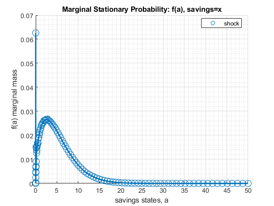

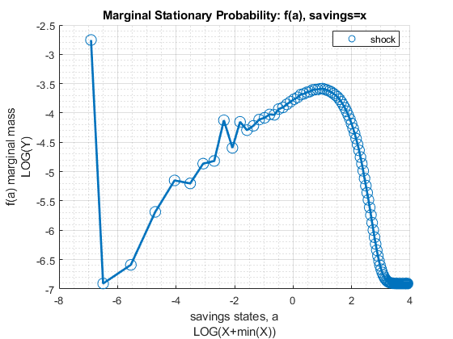

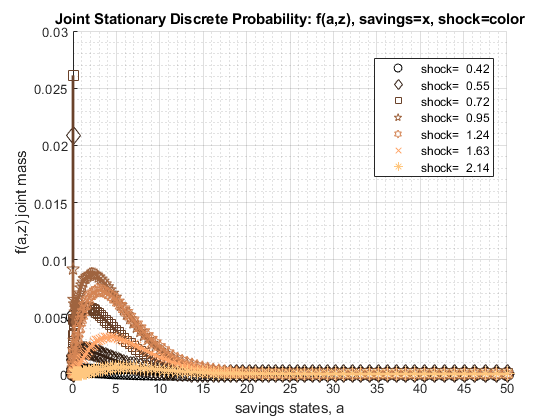

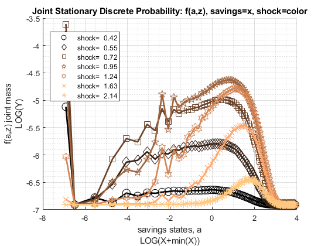

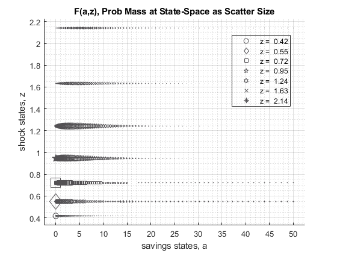

```
xxx tb_outcomes: all stats xxx
    OriginalVariableNames         ap            v             c             y            coh        savefraccoh
    ______________________    __________    __________    __________    __________    __________    ___________

    {'mean'              }        3.2216        6.9329        1.5295        1.5289        4.7511       0.52357
    {'sd'                }        3.2562        2.1508       0.34914        0.5307        3.5687       0.25504
    {'coefofvar'         }        1.0107       0.31024       0.22827       0.34711       0.75113       0.48712
    {'min'               }             0        1.7008       0.58543       0.58543       0.58543             0
    {'max'               }        50.789        19.213          4.21        4.9969        54.997       0.92702
    {'pYis0'             }      0.062608             0             0             0             0      0.062608
    {'pYls0'             }             0             0             0             0             0             0
    {'pYgr0'             }       0.93739             1             1             1             1       0.93739
    {'pYisMINY'          }      0.062608     0.0049772     0.0049772     0.0049772     0.0049772      0.062608
    {'pYisMAXY'          }    2.9501e-11    2.9501e-11    3.1223e-11    2.9501e-11    2.9501e-11     1.494e-14
    {'p0_01'             }             0        1.7008       0.58543       0.58543       0.58543             0
    {'p0_1'              }             0        1.7008       0.58543       0.58543       0.58543             0
    {'p1'                }             0        2.9492       0.76855       0.62688       0.76855             0
    {'p5'                }             0        3.4945       0.97884       0.78105         1.009             0
    {'p10'               }      0.092835        4.1716        1.0603       0.97609         1.223      0.078835
    {'p20'               }       0.47609        5.1938        1.2588        1.0456        1.7419       0.27652
    {'p25'               }        0.7311        5.3812        1.3008         1.094        2.0576       0.35312
    {'p30'               }       0.97803        5.6276         1.351         1.188        2.3618       0.42581
    {'p40'               }        1.5512        6.3139        1.4528         1.349        3.0158       0.51932
    {'p50'               }         2.233        6.8328        1.5245        1.4175        3.7588       0.59714
    {'p60'               }        3.0801         7.416        1.6192        1.5453        4.6604       0.66085
    {'p70'               }         4.105        8.0461        1.7025        1.7909        5.7649       0.70987
    {'p75'               }        4.6992        8.4292        1.7544          1.84        6.4292       0.73355
    {'p80'               }        5.4329        8.7432        1.8159        1.9097        7.3478       0.75277
    {'p90'               }        7.7004        9.7559        1.9663        2.3407        9.5263       0.79745
    {'p95'               }        9.7011        10.662        2.1066        2.5036        11.722       0.82522
    {'p99'               }        14.279        12.148        2.3613        3.1795        16.608       0.85983
    {'p99_9'             }        19.899        13.734        2.6792        3.5223        22.615        0.8829
    {'p99_99'            }        25.265        14.885        2.9563        3.7789        28.175        0.8962
    {'fl_cov_ap'         }        10.603        6.2617        1.0053        1.0453        11.608       0.65544
    {'fl_cor_ap'         }             1       0.89408        0.8843       0.60489       0.99896       0.78925
    {'fl_cov_v'          }        6.2617         4.626       0.74802       0.96794        7.0097       0.47179
    {'fl_cor_v'          }       0.89408             1       0.99613         0.848       0.91325       0.86007
    {'fl_cov_c'          }        1.0053       0.74802        0.1219       0.15425        1.1272      0.078595
    {'fl_cor_c'          }        0.8843       0.99613             1       0.83252        0.9047       0.88265
    {'fl_cov_y'          }        1.0453       0.96794       0.15425       0.28164        1.1995      0.078136
```

[output cut: 9 more lines]

```
    {'fracByP10'         }     0.0006892       0.05109      0.059758      0.051739      0.020676     0.0036864
    {'fracByP20'         }     0.0099846       0.12278        0.1366       0.12131      0.052438      0.038521
    {'fracByP25'         }      0.019425       0.15429       0.17945       0.15485      0.072434      0.070039
    {'fracByP30'         }      0.032212       0.19399       0.22206       0.19029      0.094665       0.10974
    {'fracByP40'         }        0.0737       0.28144       0.31482       0.27941       0.15063       0.20042
    {'fracByP50'         }        0.1321        0.3768       0.41124       0.37234       0.22365       0.30981
    {'fracByP60'         }       0.21336       0.48025       0.51513        0.4642       0.31463       0.42631
    {'fracByP70'         }        0.3254       0.59015       0.62157       0.57794       0.42288       0.55601
    {'fracByP75'         }       0.39769       0.65462       0.67967        0.6363       0.48537       0.62983
    {'fracByP80'         }       0.47503       0.71232       0.73844       0.70062       0.56134       0.69967
    {'fracByP90'         }       0.67403       0.84445       0.86104       0.82867       0.73331       0.84375
    {'fracByP95'         }       0.80886       0.92029       0.92647       0.90776       0.84668       0.92112
    {'fracByP99'         }       0.95057       0.98162       0.98401       0.97831       0.96163       0.98352
    {'fracByP99_9'       }       0.99336       0.99797       0.99826       0.99778       0.99494       0.99833
    {'fracByP99_99'      }       0.99924       0.99979       0.99981       0.99977        0.9994       0.99984
```

## 1.4 Test FF_DS_AZ_CTS_LOOP A grid 300 Shock grid 25

```
mp_support = containers.Map('KeyType','char', 'ValueType','any');
mp_support('bl_timer') = true;
mp_support('ls_ffcmd') = {};
mp_support('ls_ddcmd') = {};
mp_support('ls_ddgrh') = {'faz','fa'};
mp_support('bl_show_stats_table') = true;
mp_params = containers.Map('KeyType','char', 'ValueType','any');
mp_params('it_a_n') = 300;
mp_params('it_z_n') = 25;
ff_ds_az_cts_loop(mp_params, mp_support);

Elapsed time is 11.056197 seconds.
FF_DS_AZ_CTS_LOOP finished. Distribution took = 2.3435
```

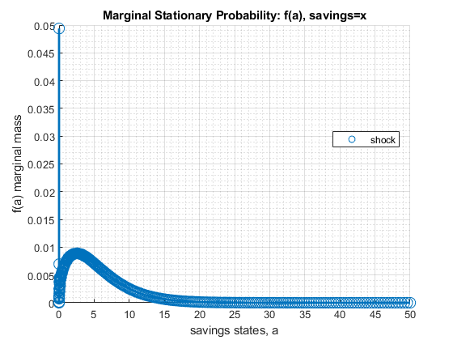

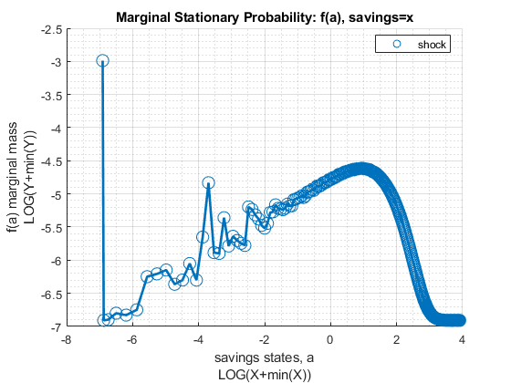

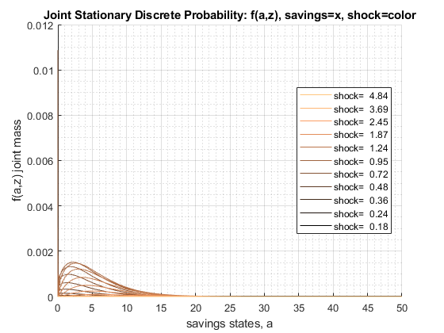

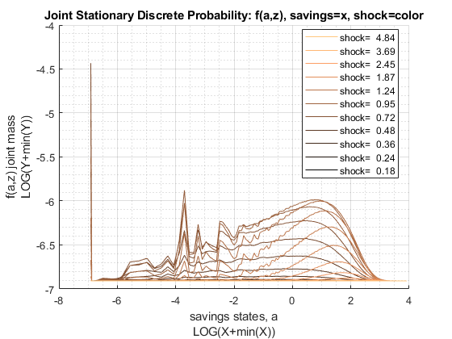

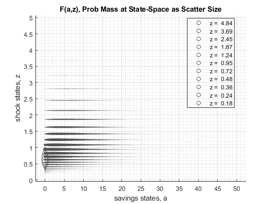

```
xxx tb_outcomes: all stats xxx
    OriginalVariableNames         ap            v             c             y            coh        savefraccoh
    ______________________    __________    __________    __________    __________    __________    ___________

    {'mean'              }        3.2612        6.9497        1.5318        1.5305         4.793       0.52715
    {'sd'                }        3.3352        2.1663       0.35078        0.5359        3.6495       0.25199
    {'coefofvar'         }        1.0227       0.31171         0.229       0.35014       0.76143       0.47803
    {'min'               }             0       -2.7616       0.25871       0.25871       0.25871             0
    {'max'               }        54.451        20.418        4.3301        8.7798         58.78       0.92837
    {'pYis0'             }       0.04941             0             0             0             0       0.04941
    {'pYls0'             }             0    7.3281e-05             0             0             0             0
    {'pYgr0'             }       0.95059       0.99993             1             1             1       0.95059
    {'pYisMINY'          }       0.04941    3.1163e-08    3.1163e-08    3.1163e-08    3.1163e-08       0.04941
    {'pYisMAXY'          }    2.8477e-13    2.8477e-13     1.121e-13    2.8477e-13    2.8477e-13    3.6157e-25
    {'p0_01'             }             0       0.33584       0.44588       0.42374       0.44588             0
    {'p0_1'              }             0        1.0287       0.51088       0.51088       0.51088             0
    {'p1'                }             0          2.33       0.67226       0.67069       0.67505             0
    {'p5'                }     0.0027154        3.5353       0.94151        0.8016        1.0088      0.002787
    {'p10'               }       0.11496        4.1978        1.0921        0.9095        1.2356      0.093483
    {'p20'               }       0.51133         5.096        1.2504        1.0657         1.779       0.28788
    {'p25'               }       0.75298        5.4004        1.3077        1.1577        2.0685       0.36173
    {'p30'               }         1.004        5.7312        1.3565        1.1951        2.3792       0.42532
    {'p40'               }        1.5834         6.298        1.4458        1.3352        3.0372       0.52408
    {'p50'               }        2.2686        6.8433        1.5287         1.441        3.7996       0.59884
    {'p60'               }        3.0898        7.4098        1.6132        1.5764        4.6904       0.65811
    {'p70'               }        4.0971        8.0297        1.7037        1.7526        5.7899       0.70877
    {'p75'               }        4.7228        8.3787        1.7552        1.8223         6.462       0.73135
    {'p80'               }        5.4827        8.7742        1.8144        1.9267        7.2769       0.75357
    {'p90'               }        7.7718        9.8224        1.9746        2.2406        9.6945       0.79922
    {'p95'               }        9.9683        10.704        2.1148        2.5163        12.048       0.82675
    {'p99'               }        14.759        12.325        2.3956         3.157        17.176       0.86245
    {'p99_9'             }        21.215        14.066        2.7525        3.9803        23.946       0.88686
    {'p99_99'            }        27.205        15.415        3.0759        4.7968        30.277       0.90047
    {'fl_cov_ap'         }        11.123        6.4528        1.0361        1.0808         12.16       0.65691
    {'fl_cor_ap'         }             1       0.89313       0.88563       0.60472         0.999       0.78162
    {'fl_cov_v'          }        6.4528        4.6928       0.75717       0.98035          7.21       0.46786
    {'fl_cor_v'          }       0.89313             1       0.99643       0.84447       0.91198       0.85705
    {'fl_cov_c'          }        1.0361       0.75717       0.12304       0.15594        1.1592       0.07767
    {'fl_cor_c'          }       0.88563       0.99643             1       0.82954       0.90548       0.87868
    {'fl_cov_y'          }        1.0808       0.98035       0.15594       0.28718        1.2368      0.077234
```

[output cut: 9 more lines]

```
    {'fracByP10'         }    0.00081444      0.049128      0.059669      0.051817      0.020124     0.0043579
    {'fracByP20'         }      0.010142       0.11647       0.13733        0.1174      0.051401      0.041452
    {'fracByP25'         }        0.0197       0.15487       0.17845       0.15395       0.07176       0.07241
    {'fracByP30'         }      0.033115       0.19474       0.22243       0.19298      0.095014       0.11033
    {'fracByP40'         }       0.07268       0.28138       0.31442       0.27544       0.15079       0.20152
    {'fracByP50'         }       0.13241        0.3756       0.41097       0.36527       0.22198       0.30736
    {'fracByP60'         }       0.21444       0.47892       0.51282       0.46572       0.31091       0.42746
    {'fracByP70'         }         0.323       0.58868       0.62139       0.57261       0.41949       0.55675
    {'fracByP75'         }       0.39061        0.6478       0.67743       0.63129       0.48319       0.62572
    {'fracByP80'         }       0.46952       0.70943       0.73587        0.6919       0.55532       0.69697
    {'fracByP90'         }       0.66831       0.84297       0.85906       0.82754       0.72955       0.84259
    {'fracByP95'         }       0.80219       0.91616       0.92541       0.90507       0.84194       0.91979
    {'fracByP99'         }       0.94613       0.98125       0.98339       0.97711       0.95822       0.98365
    {'fracByP99_9'       }        0.9927        0.9979       0.99812       0.99719       0.99443       0.99831
    {'fracByP99_99'      }       0.99909       0.99977       0.99979       0.99967       0.99932       0.99983
```

## 1.5 Test FF_DS_AZ_CTS_LOOP A grid 300 Shock grid 50

```
mp_support = containers.Map('KeyType','char', 'ValueType','any');
mp_support('bl_timer') = true;
mp_support('ls_ffcmd') = {};
mp_support('ls_ddcmd') = {};
mp_support('ls_ddgrh') = {'faz','fa'};
mp_support('bl_show_stats_table') = true;
mp_params = containers.Map('KeyType','char', 'ValueType','any');
mp_params('it_a_n') = 300;
mp_params('it_z_n') = 50;
ff_ds_az_cts_loop(mp_params, mp_support);

Elapsed time is 20.983438 seconds.
FF_DS_AZ_CTS_LOOP finished. Distribution took = 5.2169
```

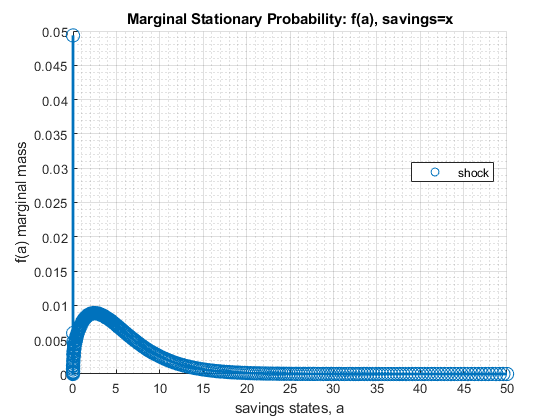

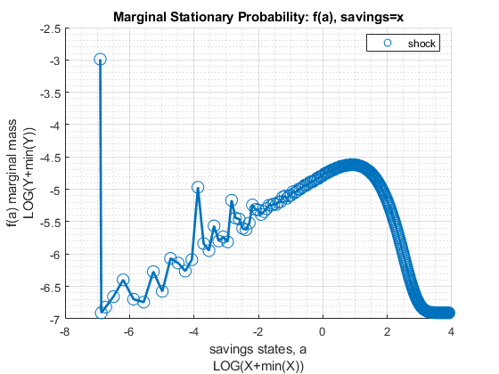

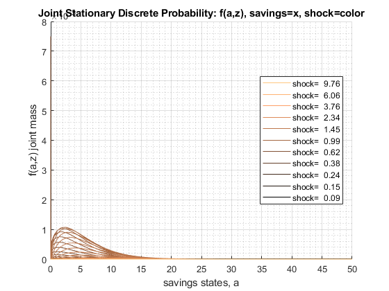

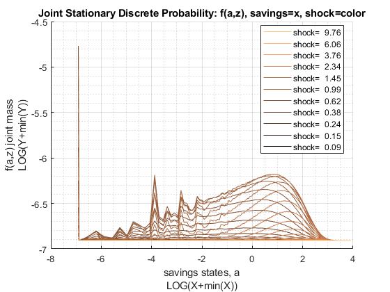

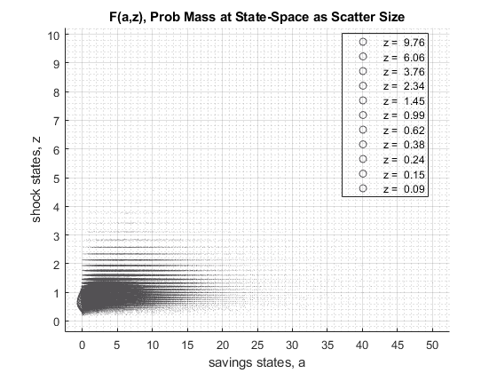

```
xxx tb_outcomes: all stats xxx
    OriginalVariableNames         ap             v             c             y            coh        savefraccoh
    ______________________    __________    ___________    __________    __________    __________    ___________

    {'mean'              }        3.2794          6.957        1.5328        1.5312        4.8122       0.52801
    {'sd'                }        3.3623         2.1722       0.35142       0.53693        3.6772       0.25195
    {'coefofvar'         }        1.0253        0.31224       0.22927       0.35065       0.76415       0.47717
    {'min'               }             0        -7.6866       0.12843       0.12843       0.12843             0
    {'max'               }        61.275         22.164        4.3849        15.657        65.657       0.93325
    {'pYis0'             }      0.049376              0             0             0             0      0.049376
    {'pYls0'             }             0     0.00011917             0             0             0             0
    {'pYgr0'             }       0.95062        0.99988             1             1             1       0.95062
    {'pYisMINY'          }      0.049376     1.1048e-15    1.1048e-15    1.1048e-15    1.1048e-15      0.049376
    {'pYisMAXY'          }     1.584e-18      1.584e-18    5.0847e-19     1.584e-18     1.584e-18     1.584e-18
    {'p0_01'             }             0       -0.20427       0.40271       0.40271       0.40271             0
    {'p0_1'              }             0         1.2141       0.53589       0.48816       0.53589             0
    {'p1'                }             0         2.3693       0.71312       0.64833       0.71312             0
    {'p5'                }      0.001023         3.5435       0.94895       0.80724       0.96945     0.0010781
    {'p10'               }       0.11645         4.2417        1.0917       0.93681        1.2501      0.095192
    {'p20'               }       0.50875           5.08        1.2515         1.072        1.7735        0.2902
    {'p25'               }       0.75899         5.4247        1.3061        1.1504        2.0649       0.36356
    {'p30'               }        1.0156         5.7325        1.3564        1.2011        2.3741       0.42667
    {'p40'               }        1.6036         6.2932        1.4459        1.3198        3.0387       0.52518
    {'p50'               }        2.2768         6.8406        1.5297        1.4423        3.8053       0.59933
    {'p60'               }        3.0945         7.4051        1.6122        1.5771        4.7002        0.6586
    {'p70'               }         4.113         8.0338        1.7042        1.7334        5.8225       0.70999
    {'p75'               }        4.7604         8.3794        1.7554        1.8278        6.4985       0.73226
    {'p80'               }        5.5142         8.7771        1.8143        1.9295        7.3239       0.75424
    {'p90'               }        7.8048         9.8378        1.9756        2.2476        9.7629       0.80013
    {'p95'               }        10.007         10.714        2.1161        2.5336        12.107       0.82766
    {'p99'               }          14.9         12.348         2.407        3.1578        17.285       0.86312
    {'p99_9'             }        21.501          14.13        2.7694        4.0322        24.216       0.88766
    {'p99_99'            }        27.735         15.514        3.1037        4.8946        30.851       0.90127
    {'fl_cov_ap'         }        11.305         6.5234        1.0466        1.0907        12.352       0.66084
    {'fl_cor_ap'         }             1        0.89316       0.88579       0.60415       0.99902       0.78009
    {'fl_cov_v'          }        6.5234         4.7186       0.76066       0.98362        7.2841       0.46879
    {'fl_cor_v'          }       0.89316              1       0.99645       0.84334        0.9119       0.85658
    {'fl_cov_c'          }        1.0466        0.76066        0.1235       0.15645        1.1701      0.077707
    {'fl_cor_c'          }       0.88579        0.99645             1       0.82914        0.9055       0.87766
    {'fl_cov_y'          }        1.0907        0.98362       0.15645        0.2883        1.2471        0.0772
```

[output cut: 9 more lines]

```
    {'fracByP10'         }    0.00082822       0.048923      0.059616      0.051792      0.020041     0.0045383
    {'fracByP20'         }      0.010119        0.11678        0.1368        0.1176      0.051426      0.041679
    {'fracByP25'         }      0.019764        0.15445       0.17846       0.15402      0.071298       0.07291
    {'fracByP30'         }      0.033198        0.19437       0.22195       0.19279      0.094487       0.11072
    {'fracByP40'         }      0.072799        0.28088       0.31405       0.27516       0.15079       0.20093
    {'fracByP50'         }       0.13186        0.37535       0.41129       0.36559       0.22202       0.30846
    {'fracByP60'         }       0.21318        0.47748       0.51316       0.46495       0.30966       0.42828
    {'fracByP70'         }       0.32222        0.58845       0.62103       0.57307       0.41837       0.55682
    {'fracByP75'         }       0.39045        0.64744       0.67785       0.63075       0.48233       0.62537
    {'fracByP80'         }       0.46786         0.7092       0.73555       0.69205       0.55399       0.69588
    {'fracByP90'         }       0.66756        0.84275        0.8587       0.82726       0.72947       0.84385
    {'fracByP95'         }       0.80166        0.91607       0.92521       0.90478       0.84112       0.91991
    {'fracByP99'         }       0.94602        0.98111       0.98335       0.97699       0.95791       0.98349
    {'fracByP99_9'       }       0.99264        0.99789        0.9981       0.99714       0.99438       0.99831
    {'fracByP99_99'      }       0.99908        0.99977       0.99979       0.99966        0.9993       0.99983
```